# k-Means Clustering

###### By Rohit Pardasani

**k-means clustering** is a method of vector quantization, originally from signal processing, that aims to partition **n observations** into **k clusters** in which each observation belongs to the cluster with the nearest mean (cluster centers or cluster centroid), serving as a prototype of the cluster.  
This results in a partitioning of the data space into **Voronoi cells**.  
In mathematics, a Voronoi diagram is a partition of a plane into regions close to each of a given set of objects. In the simplest case, these objects are just finitely many points in the plane (called seeds, sites, or generators). For each seed there is a corresponding region, called a Voronoi cell, consisting of all points of the plane closer to that seed than to any other.

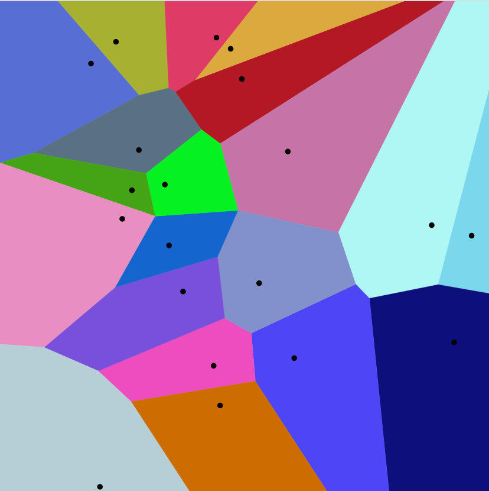

k-means clustering minimizes within-cluster variances (squared Euclidean distances), but not regular Euclidean distances.

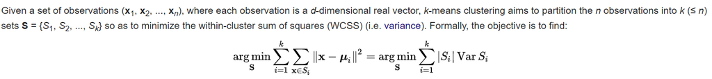

where $μ_i$ is the mean of points in $S_i$.

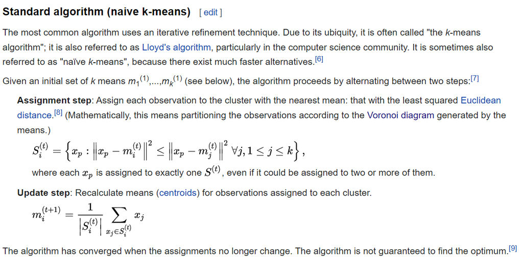

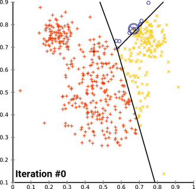

#### Initialization methods

Commonly used initialization methods are Forgy and Random Partition.  
The Forgy method randomly chooses k observations from the dataset and uses these as the initial means.  
The Random Partition method first randomly assigns a cluster to each observation and then proceeds to the update step, thus computing the initial mean to be the centroid of the cluster's randomly assigned points.  
The Forgy method tends to spread the initial means out, while Random Partition places all of them close to the center of the data set.

```
(90, 2)
```

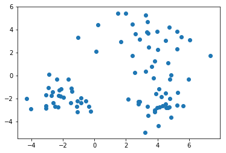

```
After k Means label assigned to all 90 samples
[1 1 1 1 1 1 1 1 1 1 1 1 1 1 1 1 1 1 1 1 1 1 1 1 1 1 1 1 1 1 0 0 0 0 0 0 0
 0 0 0 0 0 0 0 0 0 0 0 0 0 2 0 0 0 0 2 0 2 0 0 2 2 2 2 2 2 2 2 2 2 2 2 2 2
 2 2 2 2 2 2 2 2 2 2 2 2 2 2 2 2]
Cluster Centers
[[ 3.34344541  3.23665277]
 [-2.05993891 -1.92343242]
 [ 4.10716556 -2.15550331]]
```

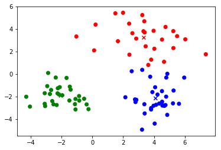

```python
import numpy as np
from sklearn.cluster import KMeans
import matplotlib.pyplot as plt
np.random.seed(1)
x1 = np.random.normal(loc=-2,scale=1.0,size=30)
y1 = np.random.normal(loc=-2,scale=1.0,size=30)
x2 = np.random.normal(loc=3,scale=2.0,size=30)
y2 = np.random.normal(loc=3,scale=2.0,size=30)
x3 = np.random.normal(loc=4,scale=1.0,size=30)
y3 = np.random.normal(loc=-2.5,scale=1.0,size=30)
x = list(x1)+list(x2)+list(x3)
y = list(y1)+list(y2)+list(y3)
X = np.zeros((len(x),2))
X[:,0] = x
X[:,1] = y
print(np.shape(X))
plt.scatter(x,y)
plt.show()
kmeans = KMeans(n_clusters=3, random_state=0).fit(X)
print('After k Means label assigned to all 90 samples ')
print(kmeans.labels_)
print('Cluster Centers')
print(kmeans.cluster_centers_)
colordict = {0:'red',1:'green',2:'blue'}
cols = [colordict[k] for k in kmeans.labels_]
plt.scatter(x,y,color=cols)
plt.scatter(kmeans.cluster_centers_[:,0],kmeans.cluster_centers_[:,1],color=['red','green','blue'],marker='x')
plt.show()
# Cluster for new sample point can be predicted using kmeans.predict(Xnew)
```

### References

https://en.wikipedia.org/wiki/K-means_clustering  
https://scikit-learn.org/stable/modules/generated/sklearn.cluster.KMeans.html